# Tidy Tuesday

Jenni Putz

2/12/2019

## Tidy Tuesday Data

The following is my first attempt at completing a #TidyTuesday. The goal was to sharpen my ggplot2 skills and learn more methods of data visualization with this package. I did not clean the data myself, I used the cleaned versions provided. Maybe in future Tidy Tuesdays, I will attempt to do this.

This week’s data came from American Association for the Advancement of Science Historical Trends and I used the cleaned versions provided by Thomas Mock on GitHub.

My main interest with this dataset was to look at some of the trends in climate spending and the EPA budget.

```r
library(tidyverse)
library(gridExtra)
library(grid)
```

```r
fed_rd <- readr::read_csv("https://raw.githubusercontent.com/rfordatascience/tidytuesday/master/data/2019/2019-02-12/fed_r_d_spending.csv")
energy_spend <- readr::read_csv("https://raw.githubusercontent.com/rfordatascience/tidytuesday/master/data/2019/2019-02-12/energy_spending.csv")
climate_spend <- readr::read_csv("https://raw.githubusercontent.com/rfordatascience/tidytuesday/master/data/2019/2019-02-12/climate_spending.csv")
```

First, I wanted to look at each dataset and plot the trends. The first graph is the R&D budget for each department of the U.S. federal government. The second is climate spending by department and the third is energy spending by department.

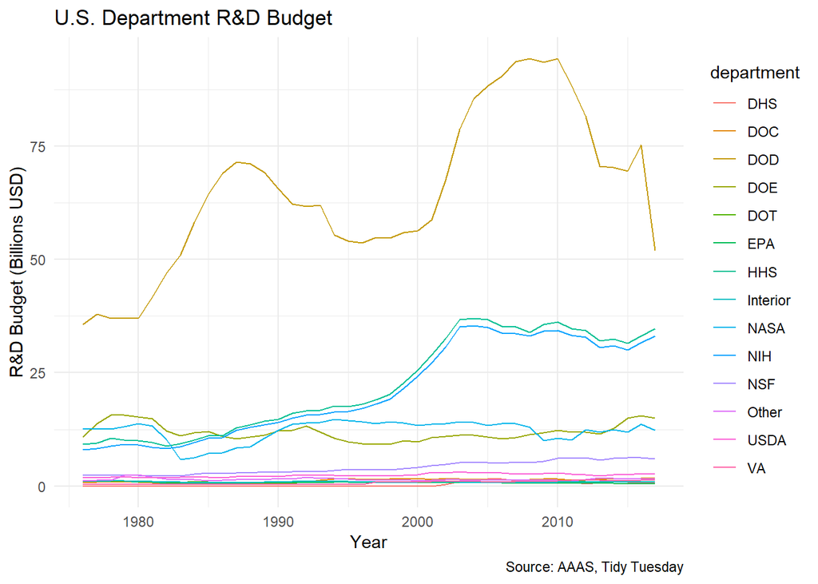

```r
plot1 <- fed_rd %>%
  ggplot(aes(x = year, y = rd_budget/1000000000, color = department)) +
  geom_line() +
  theme_minimal() +
  labs(title = "U.S. Department R&D Budget",
       x = "Year",
       y = "R&D Budget (Billions USD)",
       caption = "Source: AAAS, Tidy Tuesday")
plot1
```

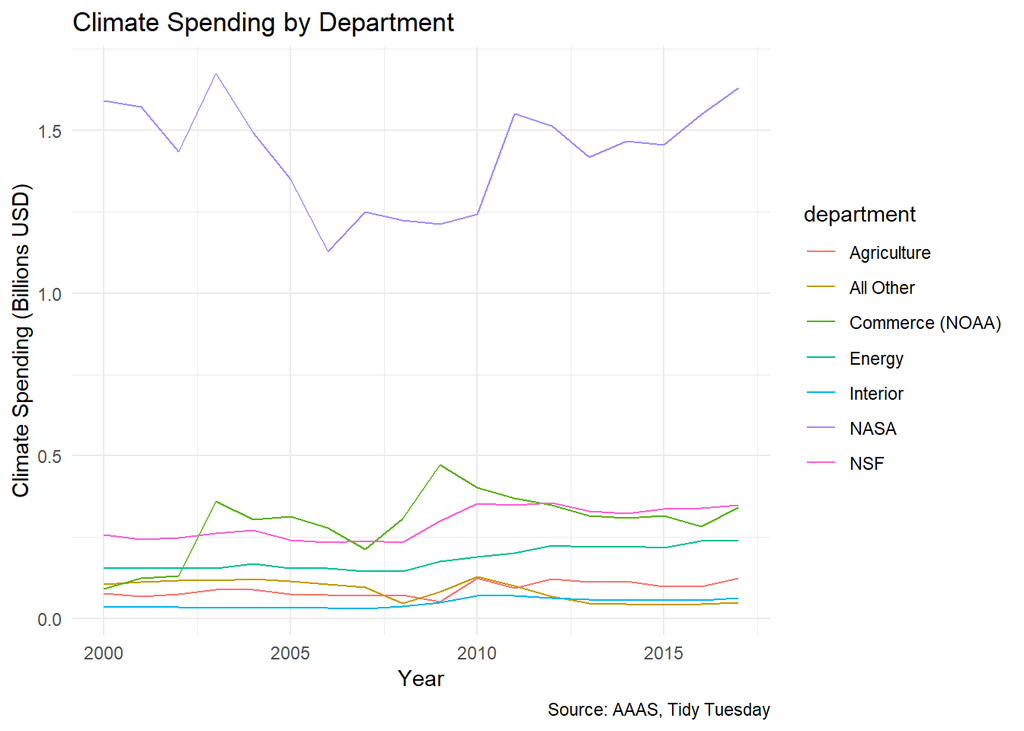

```r
plot2 <- climate_spend %>%
  ggplot(aes(x = year, y = gcc_spending/1000000000, color = department)) +
  geom_line() +
  theme_minimal() +
  labs(title = "Climate Spending by Department",
       x = "Year",
       y = "Climate Spending (Billions USD)",
       caption = "Source: AAAS, Tidy Tuesday")
plot2
```

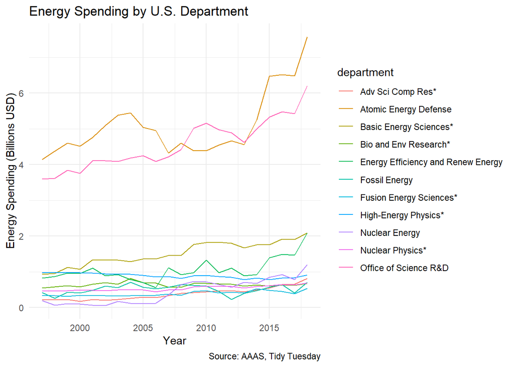

```r
plot3 <- energy_spend %>%
  ggplot(aes(x = year, y = energy_spending/1000000000, color = department)) +
  geom_line() +
  theme_minimal() +
  labs(title = "Energy Spending by U.S. Department",
       x = "Year",
       y = "Energy Spending (Billions USD)",
       caption = "Source: AAAS, Tidy Tuesday")
plot3
```

Next, I was interested in the R&D budget for the Environmental Protection Agency under various presidents. I graphed the budget with an overlay of Democratic vs Republican presidents. It appears that EPA’s R&D budget is lower under republican presidents than it is under democrats, with the exception of Obama, which is likely due to the funds being directed towards the fiscal stimulus.

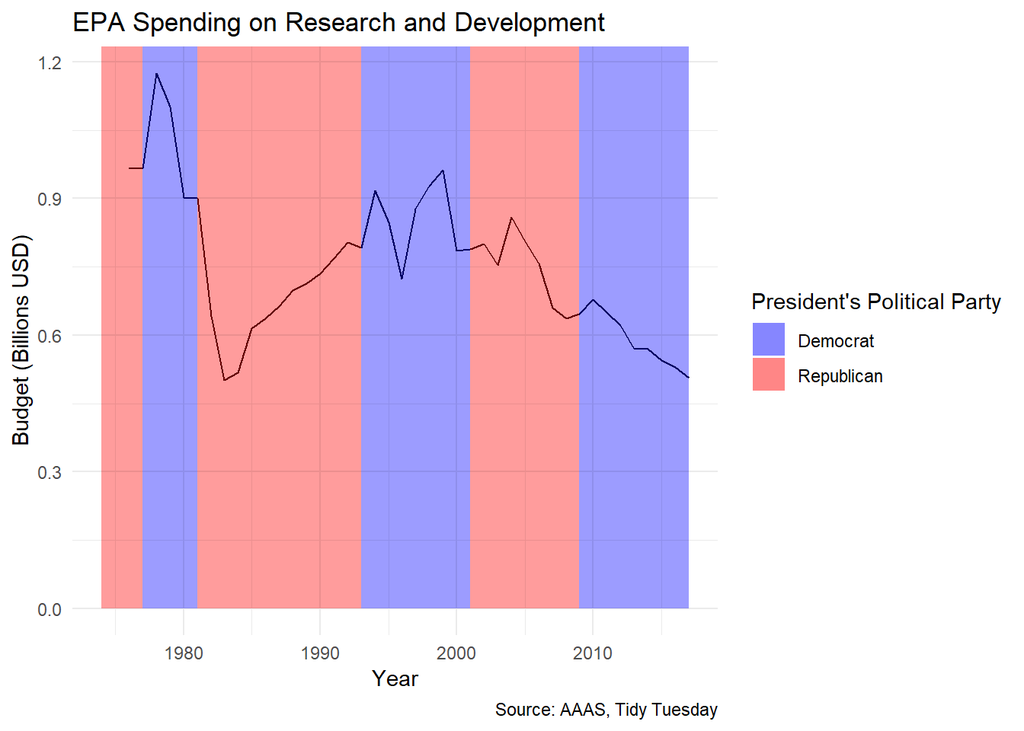

```r
political_plot <- fed_rd %>%
  filter(department == "EPA") %>%
  ggplot() +
  geom_line(aes(x = year, y = rd_budget/1000000000), color = "black") +
  geom_rect(aes(xmin = 1974, xmax = 1977, ymin = 0, ymax = Inf, fill = "Republican"), color= NA, alpha = .01) +
  geom_rect(aes(xmin = 1977, xmax = 1981, ymin = 0, ymax = Inf, fill = "Democrat"), color= NA, alpha = .01) +
  geom_rect(aes(xmin = 1981, xmax = 1993, ymin = 0, ymax = Inf, fill = "Republican"), color= NA, alpha = .01) +
  geom_rect(aes(xmin = 1993, xmax = 2001, ymin = 0, ymax = Inf, fill = "Democrat"), color= NA, alpha = .01) +
  geom_rect(aes(xmin = 2001, xmax = 2009, ymin = 0, ymax = Inf, fill = "Republican"), color= NA, alpha = .01) +
  geom_rect(aes(xmin = 2009, xmax = 2017, ymin = 0, ymax = Inf, fill = "Democrat"), color= NA, alpha = .01) +
  scale_fill_manual("President's Political Party",
                    values = c('blue', 'red'),
                    guide = guide_legend(override.aes = list(alpha = .1))) +
  scale_x_continuous() + scale_y_continuous() +
  labs(title = "EPA Spending on Research and Development",
       x = "Year",
       y = "Budget (Billions USD)",
       caption = "Source: AAAS, Tidy Tuesday") +
    theme_minimal()

political_plot
```

After looking at the EPA R&D budget, I thought it would be interesting to plot air pollution trends along side the budget. I gathered data from the EPA on various types of air pollution. I focus on PM2.5 here because this form of pollution can have a lot of health impacts on the population and is more common than other types of pollution.

```r
library(readxl)
pollution <- as.tibble(read_xlsx("pollutiondata.xlsx", sheet = 2))
```

```
## readxl works best with a newer version of the tibble package.
## You currently have tibble v1.4.2.
## Falling back to column name repair from tibble <= v1.4.2.
## Message displays once per session.
```

```r
pollution
```

```
## # A tibble: 28 x 20
##     year FUEL_COMB_ELEC_~ FUEL_COMB_INDUS~ FUEL_COMB_OTHER `CHEMICAL _ALLI~
##    <dbl>            <dbl>            <dbl>           <dbl>            <dbl>
##  1  1990             121              177             611              47
##  2  1991             105              151             638              43
##  3  1992             106              159             662              45
##  4  1993             112              172             568              41
##  5  1994             108              183             550              49
##  6  1995             107              203             589              42
##  7  1996             157.             152.            356.             38.5
##  8  1997             161.             148.            356.             39.1
##  9  1998             130.             147.            354.             39.6
## 10  1999             621.             258.            400.             45.1
## # ... with 18 more rows, and 15 more variables: METALS_PROCESSING <dbl>,
## #   PETROLEUM_RELATED_INDUSTRIES <dbl>, OTHER_INDUSTRIAL_PROCESSES <dbl>,
## #   SOLVENT_UTILIZATION <dbl>, STORAGE_TRANSPORT <dbl>, `WASTE_DISPOSAL
## #   _RECYCLING` <dbl>, HIGHWAY_VEHICLES <dbl>, OFF_HIGHWAY <dbl>,
## #   MISCELLANEOUS <dbl>, Total <dbl>, Miscellaneous <dbl>,
## #   Total_without_miscellaneous <dbl>, Wildfires <dbl>,
## #   Total_without_wildfires <dbl>, Miscellaneous_without_wildfires <dbl>
```

I thought that there could be inverse trends due to the EPA producing better technology to mitigate air pollution with a higher R&D budget. The PM2.5 appears to move in a similar trend as the R&D budget, which is interesting. Potentially, the R&D budget is decreasing because air pollution is decreasing as well.

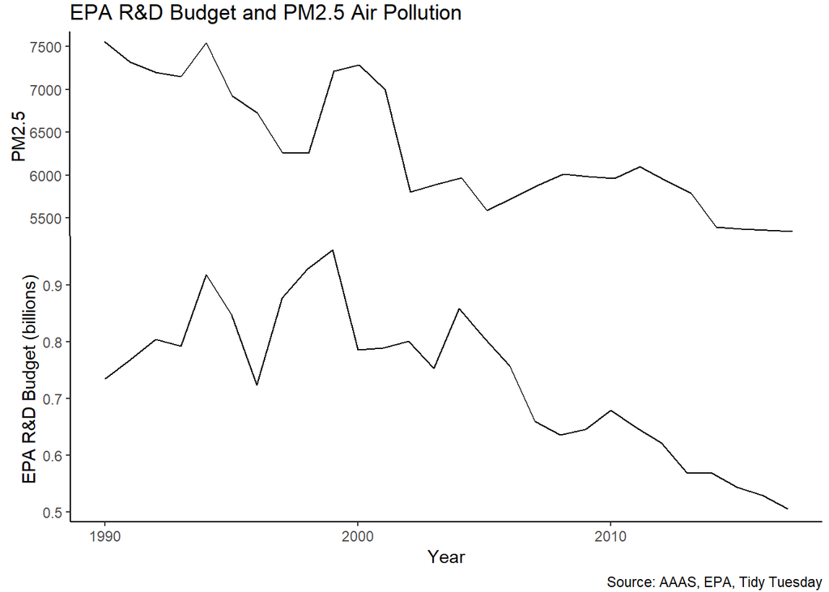

```r
g.top <- ggplot(pollution, aes(x = year, y = Total)) +
  geom_line() +
  scale_y_continuous() +
  theme_classic() +
  theme(plot.margin = unit(c(2,1,-30,5),units="points"),
        axis.title.y = element_text(vjust =0.3)) +
  labs(y = "PM2.5",
       title = "EPA R&D Budget and PM2.5 Air Pollution")

g.bottom <- ggplot(fed_rd %>% filter(department == "EPA" & year >= "1990"), aes(x = year, y = rd_budget/1000000000)) +
  geom_line() +
  theme_classic() +
  theme(plot.margin = unit(c(0,4,1,13),units="points")) +
  labs(x = "Year", y = "EPA R&D Budget (billions)",
       caption = "Source: AAAS, EPA, Tidy Tuesday")

pollution_plot <- grid.arrange(g.top,g.bottom, heights = c(2/5, 3/5))
```

```r
pollution_plot
```

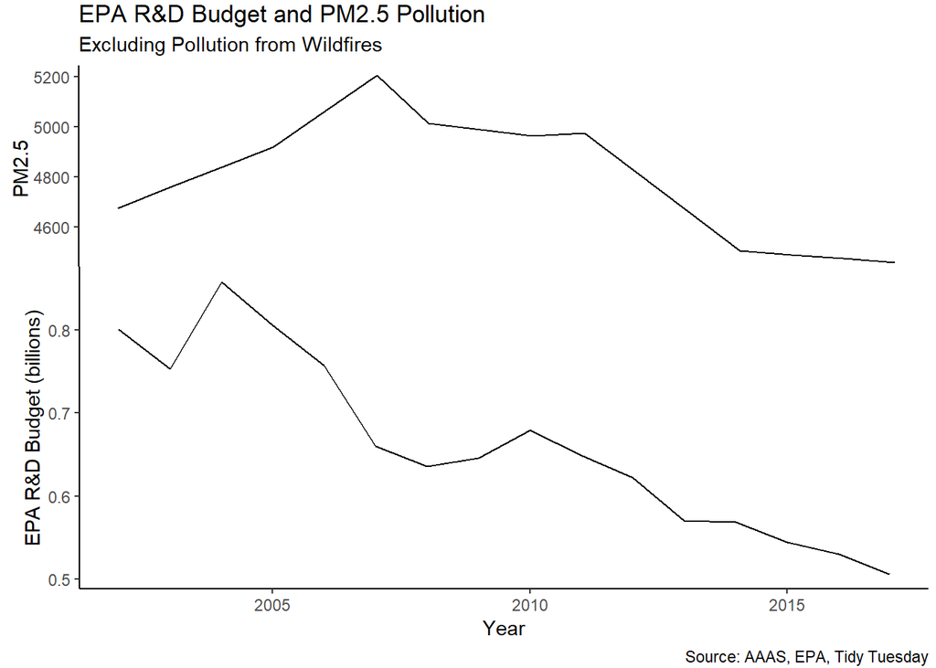

```r
g.top2 <- ggplot(pollution %>% filter(year >= "2002"), aes(x = year, y = Total_without_wildfires)) +
  geom_line() +
  scale_y_continuous() +
  theme_classic() +
  theme(plot.margin = unit(c(2,1,-30,5),units="points"),
        axis.title.y = element_text(vjust =0.3)) +
  labs(y = "PM2.5",
       title = "EPA R&D Budget and PM2.5 Pollution",
       subtitle = "Excluding Pollution from Wildfires")

g.bottom2 <- ggplot(fed_rd %>% filter(department == "EPA" & year >= "2002"), aes(x = year, y = rd_budget/1000000000)) +
  geom_line() +
  theme_classic() +
  theme(plot.margin = unit(c(0,4,1,13),units="points")) +
  labs(x = "Year", y = "EPA R&D Budget (billions)",
       caption = "Source: AAAS, EPA, Tidy Tuesday")

pollution_plot <- grid.arrange(g.top2,g.bottom2, heights = c(2/5, 3/5))
```

```r
pollution_plot
```